# Data management

2022-04-20 23:01:45

## Acknowledgements

- Support from NICHD, NIH/OD, NIMH, & NIDA via R01HD094830-01; NSF via 2032713; the LEGO Foundation; & the Alfred P. Sloan Foundation
- Karen Adolph, Cathie Tamis-LeMonda, Orit Hertzberg, Tiger Teng

## Overview

- A cautionary tale
- (Hyper)active Curation
- Lessons learned

## A cautionary tale

[video not shown]

[(NYU Health Sciences Library, 2013)](https://www.youtube.com/watch?v=66oNv_DJuPc)

## (Hyper)active curation

[figure not shown]

[(Soska et al., 2021)](http://dx.doi.org/10.7191/jeslib.2021.1208)

## What is it?

- Embed data curation within data collection workflow
- Rigorous & thorough quality assurance (QA) during collection
- Curate data with specific sharing target in mind

## Workflow

[figure not shown]

[(Soska et al., 2021)](http://dx.doi.org/10.7191/jeslib.2021.1208)

## Collection

[figure not shown]

## Coding (video annotation)

[figure not shown]

## Quality assurance (video)

- “Heavy” vs. “light” QA
- Semi-automated QA reports from Databrary
  - https://github.com/PLAY-behaviorome/workflow/tree/master/session_qa_reports
  - Not public

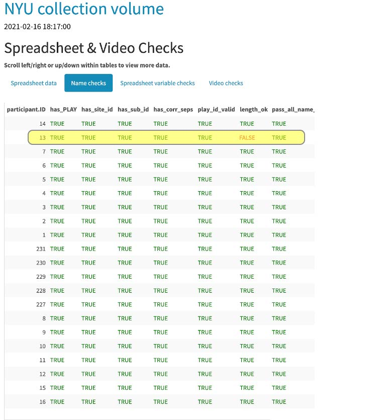

[(Soska et al., 2021)](http://dx.doi.org/10.7191/jeslib.2021.1208)

## Data export & cleaning (surveys)

- https://github.com/PLAY-behaviorome/KoBoToolbox
- Series of enumerated R Markdown documents
  - Reproducible
  - Documents gathering, cleaning steps

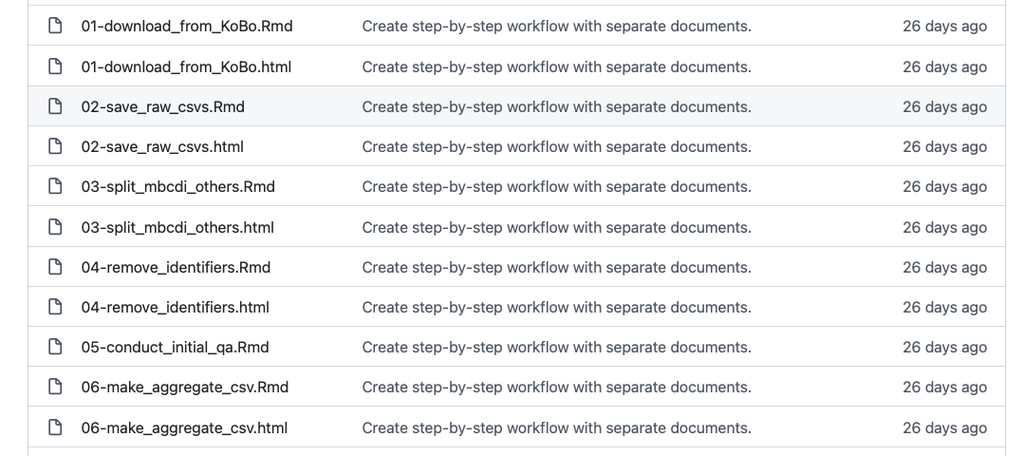

https://github.com/PLAY-behaviorome/KoBoToolbox

- Final CSV uploaded to Databrary
- `play_data <- databraryapi::read_csv_data_as_df(session_id = 51539, asset_id = 366382)`

## Summarized

[figure not shown]

[(Soska et al., 2021)](http://dx.doi.org/10.7191/jeslib.2021.1208)

## In-process

- Full protocol on https://play-project.org
- Considering migration of protocol to [`bookdown`](https://PLAY-behaviorome.github.io/protocol)
- Individual-level files
  - Including CHAT export of transcripts
- Clean, aggregate MB-CDI data
- From data dictionaries to open schemata

## Lessons learned

[figure not shown]

> “*…psychologists tend to treat other peoples’ theories like toothbrushes; no self-respecting individual wants to use anyone else’s.*”

[(Mischel, 2009)](https://www.psychologicalscience.org/observer/becoming-a-cumulative-science)

> “*The toothbrush culture undermines the building of a genuinely cumulative science, encouraging more parallel play and solo game playing, rather than building on each other’s directly relevant best work.*”

[(Mischel, 2009)](https://www.psychologicalscience.org/observer/becoming-a-cumulative-science)

> “…psychologists tend to treat other peoples’ theories data, data management practices, tasks, displays…like toothbrushes…”

*Cheeky open and reproducible developmental science advocates who want to create a more cumulative science*

## Plan your work; work your plan

- You have to curate data for yourself, so…
- Clear to you == (often) clear to others
- Curate with specific target in mind
- Automate as much as possible
  - Script, use APIs
  - Exploit the web
- Test workflow at every step/look at data
- Expect to iterate
- Don’t make the perfect the enemy of the good
- *Meaningful* data management plans increasingly [required by funders](https://psu-psychology.github.io/2021-10-01-odds-data-mgmt/)
- Make data a first class product

## Come PLAY with us!

- Share best practices
- Let’s solve as-yet-unsolved problems…together
- No reinventing wheels

[figure not shown]

https://play-project.org  
https://anhourinthelife.org  
https://PLAY-behaviorome.github.io/2022-04-21-team-sci-cds

[video not shown]

rog1@psu.edu

https://databrary.org  
https://gilmore-lab.github.io

## References

Mischel, W. (2009). Becoming a cumulative science. *APS Observer*, *22*(1). Retrieved from https://www.psychologicalscience.org/observer/becoming-a-cumulative-science

NYU Health Sciences Library. (2013, November). Data sharing and management snafu in 3 short acts (higher quality). Youtube. Retrieved from https://www.youtube.com/watch?v=66oNv_DJuPc

Soska, K. C., Xu, M., Gonzalez, S. L., Herzberg, O., Tamis-LeMonda, C. S., Gilmore, R. O., & Adolph, K. E. (2021). (Hyper)active data curation: A video case study from behavioral science. *Journal of Escience Librarianship*, *10*(3). https://doi.org/10.7191/jeslib.2021.1208